# STAT 1261: Principles of Data Science

Homework 5

1. Re-create the data graphic, “Youngest Male Names” (again, your result will be different from the chart below). You can recycle some of the codes in Lab 5. In particular, the youngest men names are given by the ascending order or `median_age`. Your chart should be restricted to birth names given to at least 100,000 male Americans since 1900. Use `filter()` to filter names with at least 100,000 `est_num_alive`. Can you make the color of the bars Carolina blue?

[figure not shown]

First, create a dataset that contains the top 25 youngest baby boy names, which were given to at least 100,000 male Americans since 1900.

```r
library(Hmisc)
library(mdsr)
library(babynames)
BabynamesDist <- make_babynames_dist()
com_male <- BabynamesDist %>%
  filter(sex == "M") %>%
  group_by(name) %>%
  mutate(est_num_alive = sum(est_alive_today)) %>%
  filter(est_num_alive >= 100000) %>%
  summarise(
    est_num_alive = sum(est_alive_today),
    q1_age = wtd.quantile(age_today, est_alive_today, probs = 0.25),
    median_age = wtd.quantile(age_today, est_alive_today, probs = 0.5),
    q3_age = wtd.quantile(age_today, est_alive_today, probs = 0.75)
  ) %>%
  arrange(median_age) %>%
  head(25)
print(com_male,n=25)
```

```
## # A tibble: 25 x 5
##    name      est_num_alive q1_age median_age q3_age
##    <chr>             <dbl>  <dbl>      <dbl>  <dbl>
##  1 Jayden          107980.      5          7      9
##  2 Gavin           123936.      6          9     14
##  3 Elijah          173815.      7         10     16
##  4 Jackson         137370.      6         10     14
##  5 Mason           146915.      7         10     16
##  6 Ethan           301045.      7         11     15
##  7 Isaiah          147352.      7         11     16
##  8 Noah            235671.      7         11     16
##  9 Angel           175908.      8         12     22
## 10 Connor          153242.      8         12     17
## 11 Logan           225776.      7         12     17
## 12 Caleb           209592.      8         13     19
## 13 Cole            105303.      8         13     18
## 14 Hunter          169352.      9         13     17
## 15 Isaac           181106.      8         13     23
## 16 Chase           120131.      8         14     20
## 17 Dylan           287499.      9         14     19
## 18 Gabriel         250119.      8         14     25
## 19 Julian          127966.      8         14     25
## 20 Lucas           153083.      8         14     23
## 21 Luke            185133.      9         14     23
## 22 Cameron         218728.     10         15     22
## 23 Dominic         108282.      9         15     27
## 24 Evan            206936.      9         15     24
## 25 Christian       342368.     10         16     22
```

Secondly, create the graphic.

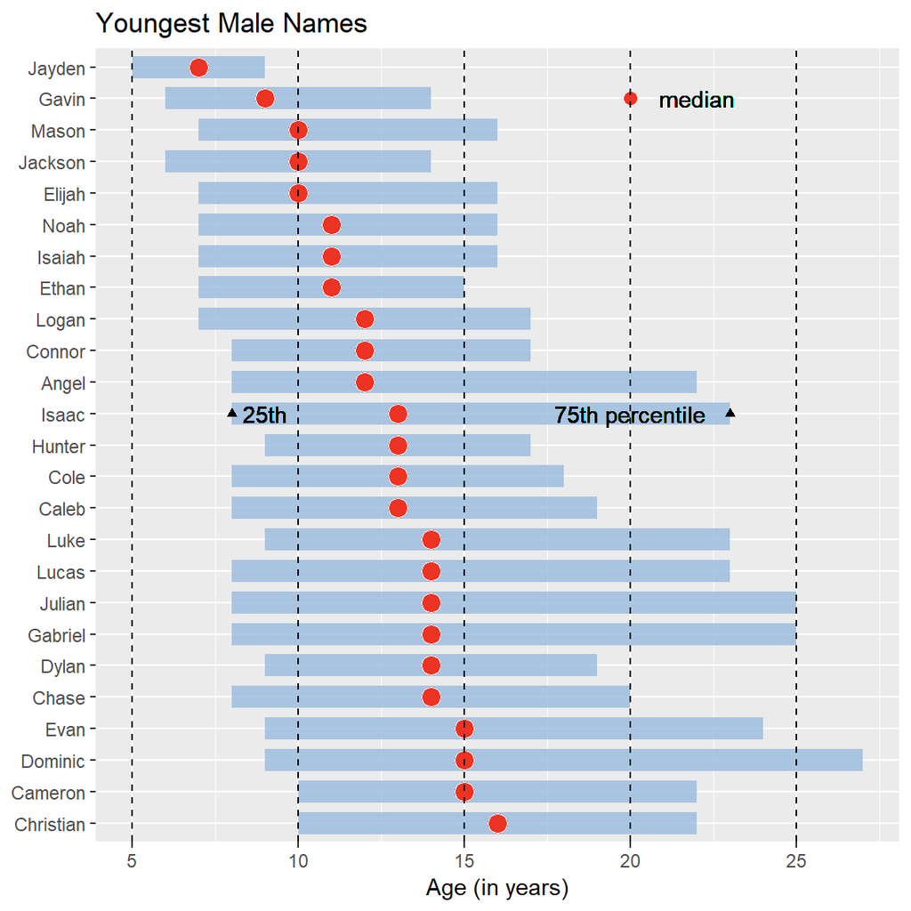

```r
w_plot <- ggplot(
  data = com_male,
  aes(x = reorder(name, -median_age),  y = median_age)
) +
  xlab(NULL) +
  ylab("Age (in years)") +
  ggtitle("Youngest Male Names")

w_plot +
  geom_linerange(
    aes(ymin = q1_age, ymax = q3_age),
    color = "#99badd",
    size = 5,
    alpha = 0.8
  ) +
  geom_point(fill = "#ed3324", colour = "white", size = 4, shape = 21) +
  geom_point(aes(y=20,x=24),fill = "#ed3324", colour = "white", size = 3, shape = 21) +
  geom_text(aes(y=22,x=24),label="median",cex=3.8)+
  geom_text(aes(y=9,x=14),label="25th",cex=3.8)+
  geom_text(aes(y=20,x=14),label="75th percentile",cex=3.8)+
  geom_point(aes(y=8,x=14),shape=17)+
  geom_point(aes(y=23,x=14),shape=17)+
  geom_hline(yintercept=seq(5,25,5),lty=2)+
  scale_y_continuous(name="Age (in years)",breaks=seq(5,25,5), labels=c("5", "10", "15", "20","25"))+
  coord_flip()
```

2. Create a new variable with value $| 0.5 - boys / total |$, using `mutate()`. List the top 10 years in which the name “Jackie” was given to M and F babies most equally. (Hint: arrange the variable created above.)

```r
Jackie <- babynames %>%
  filter(name == "Jackie") %>%
  group_by(year) %>%
  summarise(
    N = n(),
    total = sum(n),
    boys = sum(ifelse(sex == "M",n, 0))
  )  %>%
  mutate(diff0.5 = abs(0.5-boys/total)) %>%
  arrange(diff0.5) %>%
  head(10)
Jackie
```

```
## # A tibble: 10 x 5
##     year     N total  boys diff0.5
##    <dbl> <int> <int> <dbl>   <dbl>
##  1  2006     2   237   119 0.00211
##  2  1997     2   388   195 0.00258
##  3  1925     2   543   276 0.00829
##  4  1999     2   371   189 0.00943
##  5  2015     2   182    89 0.0110
##  6  1956     2  3844  1857 0.0169
##  7  1927     2   938   487 0.0192
##  8  1926     2   694   361 0.0202
##  9  2003     2   282   147 0.0213
## 10  2002     2   312   148 0.0256
```

Use `babynames` data set to answer the following questions. These questions may be challenging. Think carefully about what data transformations are needed to answer each question. In your report, include both code chunks and the result.

3. Which year had the highest number of births?

```r
HighBirth <- babynames %>%
  group_by(year) %>%
  summarise(
    total = sum(n)
  ) %>%
  arrange(desc(total)) %>%
  head(5)
HighBirth
```

```
## # A tibble: 5 x 2
##    year   total
##   <dbl>   <int>
## 1  1957 4200146
## 2  1959 4156617
## 3  1960 4154877
## 4  1961 4140040
## 5  1958 4131784
```

4. In a single pipeline, compute the earliest and latest year that each name appears.

```r
appear <- babynames %>%
  group_by(name) %>%
  summarise(
    EarliestYear= min(year),
    LatestYear = max(year)
  )
head(appear)
```

```
## # A tibble: 6 x 3
##   name      EarliestYear LatestYear
##   <chr>            <dbl>      <dbl>
## 1 Aaban             2007       2015
## 2 Aabha             2011       2015
## 3 Aabid             2003       2003
## 4 Aabriella         2008       2015
## 5 Aada              2015       2015
## 6 Aadam             1987       2015
```

5. Among popular names (let’s say at least 1% of the births in a given year), which name is the *youngest* – meaning that its first appearance as a popular name is the most recent?

```r
YoungPop <- babynames %>%
  filter(prop >= 0.01) %>%
  group_by(name) %>%
  summarise(
    EarliestYear= min(year)
  ) %>%
  arrange(desc(EarliestYear)) %>%
  head(10)
YoungPop
```

```
## # A tibble: 10 x 2
##    name     EarliestYear
##    <chr>           <dbl>
##  1 Olivia           2014
##  2 Sophia           2010
##  3 Isabella         2009
##  4 Ethan            2002
##  5 Madison          2000
##  6 Alexis           1998
##  7 Hannah           1997
##  8 Austin           1994
##  9 Taylor           1993
## 10 Emily            1992
```

6. It seems like there is more diversity of names now than in the past. How have the number of names used changed over time? Has it been the same for boys and girls?

We can use a graphic to show the trend.

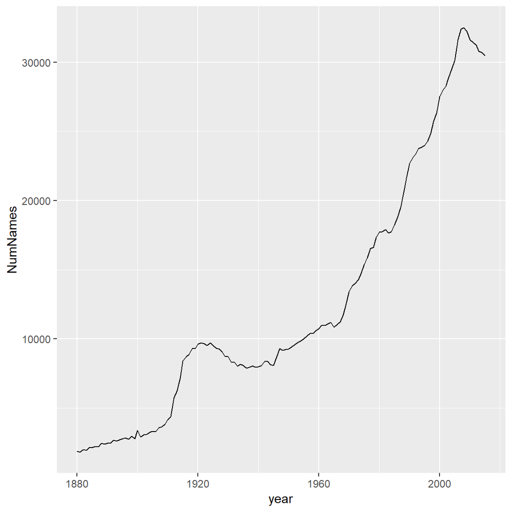

```r
NumNames <- babynames %>%
  group_by(year) %>%
  summarise(
#    NumNames=length(unique(name))
    NumNames=n_distinct(name)
  )
ggplot(NumNames,mapping=aes(x=year,y=NumNames))+
  geom_line()
```

Use facets to compare trends between genders.

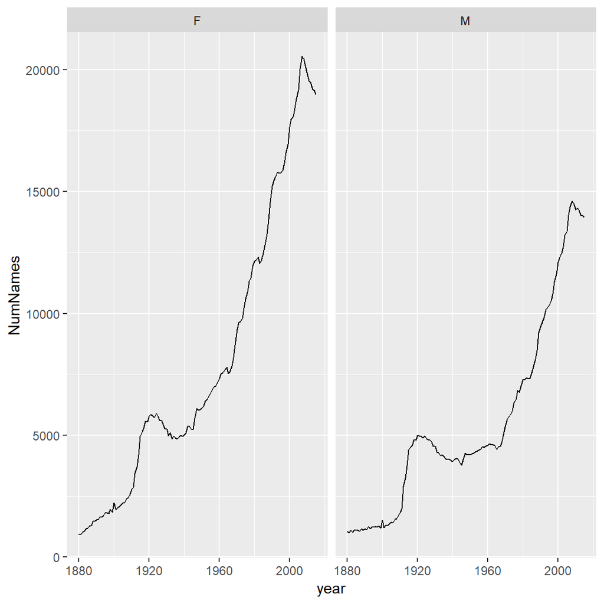

```r
NumNames2 <- babynames %>%
  group_by(year,sex,add=TRUE) %>%
  summarise(
    NumNames=n_distinct(name)
  )

ggplot(NumNames2,mapping=aes(x=year,y=NumNames))+
  geom_line()+
  facet_wrap(~sex)
```

7. Find the most popular names of the 1990s.

```r
Popular90s <- babynames %>%
  group_by(name) %>%
  filter(year >=1990 & year < 2000) %>%
  summarise(
    total=sum(n)
  ) %>%
  arrange(desc(total)) %>%
  head(10)

Popular90s
```

```
## # A tibble: 10 x 2
##    name         total
##    <chr>        <int>
##  1 Michael     464221
##  2 Christopher 361234
##  3 Matthew     352320
##  4 Joshua      330029
##  5 Jessica     303837
##  6 Ashley      303113
##  7 Jacob       298871
##  8 Nicholas    275899
##  9 Andrew      273475
## 10 Daniel      273274
```